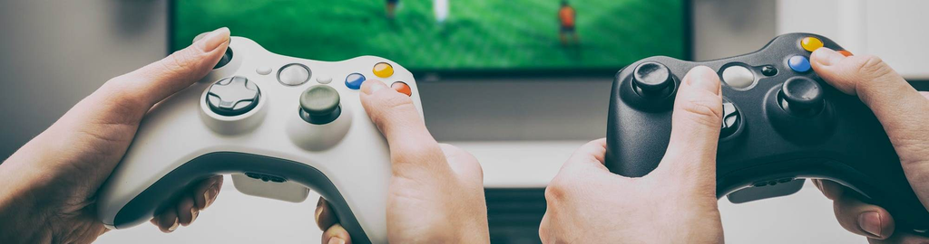

# Анализ продаж интернет-магазина "Стримчик" за 2016 год

Введение:

Интернет-магазин «Стримчик» продаёт по всему миру компьютерные игры. Из открытых источников доступны исторические данные о продажах игр, оценки пользователей и экспертов, жанры и платформы (например, Xbox или PlayStation). Нам нужно выявить определяющие успешность игры закономерности. Это позволит сделать ставку на потенциально популярный продукт и спланировать рекламные кампании на будущий год.

Необходимые исследования:

- Необходимо посмотреть, сколько игр выпускалось в разные годы. И важны ли данные за все периоды?
- Как менялись продажи по платформам. Нужно выберать платформы с наибольшими суммарными продажами и построить распределение по годам. За какой характерный срок появляются новые и исчезают старые платформы?

Необходимо взять данные за соответствующий актуальный период. Актуальный период необходимо определить самостоятельно в результате исследования предыдущих вопросов. Основной фактор — эти данные помогут построить прогноз на 2017 год. Не нужно учитывать в работе данные за предыдущие годы.

- Какие платформы лидируют по продажам, растут или падают? Нужно выбрать несколько потенциально прибыльных платформ.
- Построть график «ящик с усами» по глобальным продажам игр в разбивке по платформам. Описать результат.
- Посмотреть, как влияют на продажи внутри одной популярной платформы отзывы пользователей и критиков. Построить диаграмму рассеяния и посчитать корреляцию между отзывами и продажами. Сформулировать выводы. Соотнести выводы с продажами игр на других платформах.
- Посмотреть на общее распределение игр по жанрам. Что можно сказать о самых прибыльных жанрах? Выделяются ли жанры с высокими и низкими продажами?

Необходимо составить портрет пользователя каждого региона. Определить для пользователя каждого региона (NA, EU, JP):

- Самые популярные платформы (топ-5). Описать различия в долях продаж.
- Самые популярные жанры (топ-5). Пояснить разницу.
- Влияет ли рейтинг ESRB на продажи в отдельном регионе?

Проверить гипотезы:

- Средние пользовательские рейтинги платформ Xbox One и PC одинаковые;
- Средние пользовательские рейтинги жанров Action (англ. «действие», экшен-игры) и Sports (англ. «спортивные соревнования») разные.

План отчета:

1. Закомство с данными
2. Предобработка данных
3. Исследовательский анализ данных
4. Портрет пользователя каждого региона
5. Проверка гипотез
6. Выводы

#### Шаг 1. Знакомство с данными.

```python
#  подключаем необходимые для разбора библиотеки

import pandas as pd
import numpy as np
import matplotlib.pyplot as plt
from scipy import stats as st
import seaborn as sns
import matplotlib.ticker
```

```python
# посмотрим данные из файла "users_go.csv"

data_games = pd.read_csv('/datasets/games.csv')

data_games.head()
```

|  | Name | Platform | Year_of_Release | Genre | NA_sales | EU_sales | JP_sales | Other_sales | Critic_Score | User_Score | Rating |
| --- | --- | --- | --- | --- | --- | --- | --- | --- | --- | --- | --- |
| 0 | Wii Sports | Wii | 2006.0 | Sports | 41.36 | 28.96 | 3.77 | 8.45 | 76.0 | 8 | E |
| 1 | Super Mario Bros. | NES | 1985.0 | Platform | 29.08 | 3.58 | 6.81 | 0.77 | NaN | NaN | NaN |
| 2 | Mario Kart Wii | Wii | 2008.0 | Racing | 15.68 | 12.76 | 3.79 | 3.29 | 82.0 | 8.3 | E |
| 3 | Wii Sports Resort | Wii | 2009.0 | Sports | 15.61 | 10.93 | 3.28 | 2.95 | 80.0 | 8 | E |
| 4 | Pokemon Red/Pokemon Blue | GB | 1996.0 | Role-Playing | 11.27 | 8.89 | 10.22 | 1.00 | NaN | NaN | NaN |

```python
data_games.info()
```

```
<class 'pandas.core.frame.DataFrame'>
RangeIndex: 16715 entries, 0 to 16714
Data columns (total 11 columns):
 #   Column           Non-Null Count  Dtype
---  ------           --------------  -----
 0   Name             16713 non-null  object
 1   Platform         16715 non-null  object
 2   Year_of_Release  16446 non-null  float64
 3   Genre            16713 non-null  object
 4   NA_sales         16715 non-null  float64
 5   EU_sales         16715 non-null  float64
 6   JP_sales         16715 non-null  float64
 7   Other_sales      16715 non-null  float64
 8   Critic_Score     8137 non-null   float64
 9   User_Score       10014 non-null  object
 10  Rating           9949 non-null   object
dtypes: float64(6), object(5)
memory usage: 1.4+ MB
```

Вывод Шага 1:

- База содержит данные о 16 713 играх.
- Нулевых значений нет.
- Есть пропущенные значения в столбцах: ** Critic_Score ** User_Score ** Rating ** Year_of_Release ** Name ** Genre
- Наименования столбцов логичные, но написаны с заглавной буквы.
- Тип данных стобца User_Score не соответствует содержанию. Year_of_Release можно сделать типа int.

#### Шаг 2. Предобработка данных.

Приведем названия столбцов к нижнему регистру.

```python
data_games.columns = data_games.columns.str.lower()

data_games.head()
```

|  | name | platform | year_of_release | genre | na_sales | eu_sales | jp_sales | other_sales | critic_score | user_score | rating |
| --- | --- | --- | --- | --- | --- | --- | --- | --- | --- | --- | --- |
| 0 | Wii Sports | Wii | 2006.0 | Sports | 41.36 | 28.96 | 3.77 | 8.45 | 76.0 | 8 | E |
| 1 | Super Mario Bros. | NES | 1985.0 | Platform | 29.08 | 3.58 | 6.81 | 0.77 | NaN | NaN | NaN |
| 2 | Mario Kart Wii | Wii | 2008.0 | Racing | 15.68 | 12.76 | 3.79 | 3.29 | 82.0 | 8.3 | E |
| 3 | Wii Sports Resort | Wii | 2009.0 | Sports | 15.61 | 10.93 | 3.28 | 2.95 | 80.0 | 8 | E |
| 4 | Pokemon Red/Pokemon Blue | GB | 1996.0 | Role-Playing | 11.27 | 8.89 | 10.22 | 1.00 | NaN | NaN | NaN |

```python
# приведем занчения столбцов name, platform к строчному написанию

data_games['name'] = data_games['name'].str.lower()
data_games['platform'] = data_games['platform'].str.lower()
data_games['genre'] = data_games['genre'].str.lower()

data_games.head()
```

|  | name | platform | year_of_release | genre | na_sales | eu_sales | jp_sales | other_sales | critic_score | user_score | rating |
| --- | --- | --- | --- | --- | --- | --- | --- | --- | --- | --- | --- |
| 0 | wii sports | wii | 2006.0 | sports | 41.36 | 28.96 | 3.77 | 8.45 | 76.0 | 8 | E |
| 1 | super mario bros. | nes | 1985.0 | platform | 29.08 | 3.58 | 6.81 | 0.77 | NaN | NaN | NaN |
| 2 | mario kart wii | wii | 2008.0 | racing | 15.68 | 12.76 | 3.79 | 3.29 | 82.0 | 8.3 | E |
| 3 | wii sports resort | wii | 2009.0 | sports | 15.61 | 10.93 | 3.28 | 2.95 | 80.0 | 8 | E |
| 4 | pokemon red/pokemon blue | gb | 1996.0 | role-playing | 11.27 | 8.89 | 10.22 | 1.00 | NaN | NaN | NaN |

```python
# проверим за какие года у нас есть данные

data_games['year_of_release'].unique() #.sort_values()
```

```
array([2006., 1985., 2008., 2009., 1996., 1989., 1984., 2005., 1999.,
       2007., 2010., 2013., 2004., 1990., 1988., 2002., 2001., 2011.,
       1998., 2015., 2012., 2014., 1992., 1997., 1993., 1994., 1982.,
       2016., 2003., 1986., 2000.,   nan, 1995., 1991., 1981., 1987.,
       1980., 1983.])
```

Удалим строки, где нет данных о годе выпуска игры, тк при дальнейшем анализе для нас это важно.

```python
# выделим строки, в которых год пропущен в отдельный столбец, в котором посчитаем число всех продаж по данным
# с пропущенным годом

data_sum = data_games.loc[data_games['year_of_release'].isna(), ['na_sales', 'eu_sales', 'jp_sales', 'other_sales']].sum(axis=1)

# посмотрим сколько всего в нем строк

data_sum.count()
```

```
269
```

```python
# просуммируем данные в этом столбе - узнаем общую сумму продаж на 269 игр

round(data_sum.sum(),2)
```

```
98.92
```

```python
data_games = data_games.dropna(subset=['year_of_release'])

data_games.info()
```

```
<class 'pandas.core.frame.DataFrame'>
Int64Index: 16446 entries, 0 to 16714
Data columns (total 11 columns):
 #   Column           Non-Null Count  Dtype
---  ------           --------------  -----
 0   name             16444 non-null  object
 1   platform         16446 non-null  object
 2   year_of_release  16446 non-null  float64
 3   genre            16444 non-null  object
 4   na_sales         16446 non-null  float64
 5   eu_sales         16446 non-null  float64
 6   jp_sales         16446 non-null  float64
 7   other_sales      16446 non-null  float64
 8   critic_score     7983 non-null   float64
 9   user_score       9839 non-null   object
 10  rating           9768 non-null   object
dtypes: float64(6), object(5)
memory usage: 1.5+ MB
```

Сделаем столбец year_of_release типа данных int

```python
data_games['year_of_release'] = data_games['year_of_release'].astype('int')
data_games.info()
```

```
<class 'pandas.core.frame.DataFrame'>
Int64Index: 16446 entries, 0 to 16714
Data columns (total 11 columns):
 #   Column           Non-Null Count  Dtype
---  ------           --------------  -----
 0   name             16444 non-null  object
 1   platform         16446 non-null  object
 2   year_of_release  16446 non-null  int64
 3   genre            16444 non-null  object
 4   na_sales         16446 non-null  float64
 5   eu_sales         16446 non-null  float64
 6   jp_sales         16446 non-null  float64
 7   other_sales      16446 non-null  float64
 8   critic_score     7983 non-null   float64
 9   user_score       9839 non-null   object
 10  rating           9768 non-null   object
dtypes: float64(5), int64(1), object(5)
memory usage: 1.5+ MB
```

```python
# посмотрим, что у нас в столбце значений name

data_games['name'].unique()
```

```
array(['wii sports', 'super mario bros.', 'mario kart wii', ...,
       'woody woodpecker in crazy castle 5', 'lma manager 2007',
       'haitaka no psychedelica'], dtype=object)
```

```python
# проверим пропуски в столбце name

data_games['name'].isna().sum()
```

```
2
```

Удалим два пропуска в столбце 'name' , тк нам важны наименования игр при дальнейшем анализе.

```python
data_games = data_games.dropna(subset=['name'])

data_games.info()
```

```
<class 'pandas.core.frame.DataFrame'>
Int64Index: 16444 entries, 0 to 16714
Data columns (total 11 columns):
 #   Column           Non-Null Count  Dtype
---  ------           --------------  -----
 0   name             16444 non-null  object
 1   platform         16444 non-null  object
 2   year_of_release  16444 non-null  int64
 3   genre            16444 non-null  object
 4   na_sales         16444 non-null  float64
 5   eu_sales         16444 non-null  float64
 6   jp_sales         16444 non-null  float64
 7   other_sales      16444 non-null  float64
 8   critic_score     7983 non-null   float64
 9   user_score       9839 non-null   object
 10  rating           9768 non-null   object
dtypes: float64(5), int64(1), object(5)
memory usage: 1.5+ MB
```

```python
# посмотрим, что у нас в столбце значений user_score

data_games['user_score'].unique()
```

```
array(['8', nan, '8.3', '8.5', '6.6', '8.4', '8.6', '7.7', '6.3', '7.4',
       '8.2', '9', '7.9', '8.1', '8.7', '7.1', '3.4', '5.3', '4.8', '3.2',
       '8.9', '6.4', '7.8', '7.5', '2.6', '7.2', '9.2', '7', '7.3', '4.3',
       '7.6', '5.7', '5', '9.1', '6.5', 'tbd', '8.8', '6.9', '9.4', '6.8',
       '6.1', '6.7', '5.4', '4', '4.9', '4.5', '9.3', '6.2', '4.2', '6',
       '3.7', '4.1', '5.8', '5.6', '5.5', '4.4', '4.6', '5.9', '3.9',
       '3.1', '2.9', '5.2', '3.3', '4.7', '5.1', '3.5', '2.5', '1.9', '3',
       '2.7', '2.2', '2', '9.5', '2.1', '3.6', '2.8', '1.8', '3.8', '0',
       '1.6', '9.6', '2.4', '1.7', '1.1', '0.3', '1.5', '0.7', '1.2',
       '2.3', '0.5', '1.3', '0.2', '0.6', '1.4', '0.9', '1', '9.7'],
      dtype=object)
```

```python
# проверим число оценок 'tbd'

len(data_games[data_games['user_score'] == 'tbd'].index)
```

```
2376
```

Оценка 'tbd' - сленговая среди геймеров, не относится к числовому показателю. Убрать строки с этой оценкой - значит потерять часть данных. Чтобы полноценно пользоваться этими данными, сделаем эту оценку Nan. Сам столбец user_score переведем в тип данных float.

```python
data_games['user_score'] = pd.to_numeric(data_games['user_score'], errors = 'coerce')

data_games.info()
```

```
<class 'pandas.core.frame.DataFrame'>
Int64Index: 16444 entries, 0 to 16714
Data columns (total 11 columns):
 #   Column           Non-Null Count  Dtype
---  ------           --------------  -----
 0   name             16444 non-null  object
 1   platform         16444 non-null  object
 2   year_of_release  16444 non-null  int64
 3   genre            16444 non-null  object
 4   na_sales         16444 non-null  float64
 5   eu_sales         16444 non-null  float64
 6   jp_sales         16444 non-null  float64
 7   other_sales      16444 non-null  float64
 8   critic_score     7983 non-null   float64
 9   user_score       7463 non-null   float64
 10  rating           9768 non-null   object
dtypes: float64(6), int64(1), object(4)
memory usage: 1.5+ MB
```

```python
# посчитаем пропущенные значения в user_score

data_games['user_score'].isna().sum()
```

```
8981
```

Не будем заполнять пропуски в связи с разнорожностью данных. Оставим их как неизвестные.

```python
# посмотрим, что у нас в столбце значений rating

data_games['rating'].unique()
```

```
array(['E', nan, 'M', 'T', 'E10+', 'K-A', 'AO', 'EC', 'RP'], dtype=object)
```

Согласно данным из [Википедии](https://ru.wikipedia.org/wiki/Entertainment_Software_Rating_Board) в разделении на категории Entertainment Software Rating Board, категории Е и К-А - это одно и тоже. Переименуем категорию К-А в Е. Пропуски заполним значением категории - RP - то есть, "рейтинг ожидается".

```python
data_games.loc[data_games['rating'] == 'K-A','rating'] = 'E'

data_games['rating'].unique()
```

```
array(['E', nan, 'M', 'T', 'E10+', 'AO', 'EC', 'RP'], dtype=object)
```

```python
# проверим, что не потеряли данные

data_games.info()
```

```
<class 'pandas.core.frame.DataFrame'>
Int64Index: 16444 entries, 0 to 16714
Data columns (total 11 columns):
 #   Column           Non-Null Count  Dtype
---  ------           --------------  -----
 0   name             16444 non-null  object
 1   platform         16444 non-null  object
 2   year_of_release  16444 non-null  int64
 3   genre            16444 non-null  object
 4   na_sales         16444 non-null  float64
 5   eu_sales         16444 non-null  float64
 6   jp_sales         16444 non-null  float64
 7   other_sales      16444 non-null  float64
 8   critic_score     7983 non-null   float64
 9   user_score       7463 non-null   float64
 10  rating           9768 non-null   object
dtypes: float64(6), int64(1), object(4)
memory usage: 1.5+ MB
```

```python
# заполним пропуски столбца 'rating' значением RP

data_games['rating'] = data_games['rating'].fillna('RP')

data_games.info()
```

```
<class 'pandas.core.frame.DataFrame'>
Int64Index: 16444 entries, 0 to 16714
Data columns (total 11 columns):
 #   Column           Non-Null Count  Dtype
---  ------           --------------  -----
 0   name             16444 non-null  object
 1   platform         16444 non-null  object
 2   year_of_release  16444 non-null  int64
 3   genre            16444 non-null  object
 4   na_sales         16444 non-null  float64
 5   eu_sales         16444 non-null  float64
 6   jp_sales         16444 non-null  float64
 7   other_sales      16444 non-null  float64
 8   critic_score     7983 non-null   float64
 9   user_score       7463 non-null   float64
 10  rating           16444 non-null  object
dtypes: float64(6), int64(1), object(4)
memory usage: 1.5+ MB
```

```python
# посмотрим, что у нас в столбце значений critic_score

data_games['critic_score'].unique()
```

```
array([76., nan, 82., 80., 89., 58., 87., 91., 61., 97., 95., 77., 88.,
       83., 94., 93., 85., 86., 98., 96., 90., 84., 73., 74., 78., 92.,
       71., 72., 68., 62., 49., 67., 81., 66., 56., 79., 70., 59., 64.,
       75., 60., 63., 69., 50., 25., 42., 44., 55., 48., 57., 29., 47.,
       65., 54., 20., 53., 37., 38., 33., 52., 30., 32., 43., 45., 51.,
       40., 46., 39., 34., 41., 36., 31., 27., 35., 26., 19., 28., 23.,
       24., 21., 17., 13.])
```

Не будем заполнять пропуски в связи с разнорожностью данных. Оставим их как неизвестные.

```python
# убедимся, что пропусков значений нет

data_games.isna().sum()
```

```
name                  0
platform              0
year_of_release       0
genre                 0
na_sales              0
eu_sales              0
jp_sales              0
other_sales           0
critic_score       8461
user_score         8981
rating                0
dtype: int64
```

Проверим данные на явные дубликаты.

```python
data_games.duplicated().sum()
```

```
0
```

```python
# проверим данные на неполные дубликаты

data_games.duplicated(subset=['name', 'platform', 'year_of_release']).sum()
```

```
1
```

```python
# удаляем неполные дубликаты

data_games = data_games.drop_duplicates(subset=['name', 'platform', 'year_of_release'])
```

```python
# проверим данные на неполные дубликаты  снова

data_games.duplicated(subset=['name', 'platform', 'year_of_release']).sum()
```

```
0
```

```python
data_games.head(10)
```

|  | name | platform | year_of_release | genre | na_sales | eu_sales | jp_sales | other_sales | critic_score | user_score | rating |
| --- | --- | --- | --- | --- | --- | --- | --- | --- | --- | --- | --- |
| 0 | wii sports | wii | 2006 | sports | 41.36 | 28.96 | 3.77 | 8.45 | 76.0 | 8.0 | E |
| 1 | super mario bros. | nes | 1985 | platform | 29.08 | 3.58 | 6.81 | 0.77 | NaN | NaN | RP |
| 2 | mario kart wii | wii | 2008 | racing | 15.68 | 12.76 | 3.79 | 3.29 | 82.0 | 8.3 | E |
| 3 | wii sports resort | wii | 2009 | sports | 15.61 | 10.93 | 3.28 | 2.95 | 80.0 | 8.0 | E |
| 4 | pokemon red/pokemon blue | gb | 1996 | role-playing | 11.27 | 8.89 | 10.22 | 1.00 | NaN | NaN | RP |
| 5 | tetris | gb | 1989 | puzzle | 23.20 | 2.26 | 4.22 | 0.58 | NaN | NaN | RP |
| 6 | new super mario bros. | ds | 2006 | platform | 11.28 | 9.14 | 6.50 | 2.88 | 89.0 | 8.5 | E |
| 7 | wii play | wii | 2006 | misc | 13.96 | 9.18 | 2.93 | 2.84 | 58.0 | 6.6 | E |
| 8 | new super mario bros. wii | wii | 2009 | platform | 14.44 | 6.94 | 4.70 | 2.24 | 87.0 | 8.4 | E |
| 9 | duck hunt | nes | 1984 | shooter | 26.93 | 0.63 | 0.28 | 0.47 | NaN | NaN | RP |

```python
# посчитаем, сколько данных у нас осталось после обработки

data_games_before = pd.read_csv('/datasets/games.csv')

round(len(data_games.index)/len(data_games_before.index), 2)
```

```
0.98
```

Добавим столбец с суммарными продажами по всем регионам.

```python
data_games['total_sales'] = data_games[['na_sales','eu_sales','jp_sales', 'other_sales']].sum(axis = 1)
data_games.head()
```

|  | name | platform | year_of_release | genre | na_sales | eu_sales | jp_sales | other_sales | critic_score | user_score | rating | total_sales |
| --- | --- | --- | --- | --- | --- | --- | --- | --- | --- | --- | --- | --- |
| 0 | wii sports | wii | 2006 | sports | 41.36 | 28.96 | 3.77 | 8.45 | 76.0 | 8.0 | E | 82.54 |
| 1 | super mario bros. | nes | 1985 | platform | 29.08 | 3.58 | 6.81 | 0.77 | NaN | NaN | RP | 40.24 |
| 2 | mario kart wii | wii | 2008 | racing | 15.68 | 12.76 | 3.79 | 3.29 | 82.0 | 8.3 | E | 35.52 |
| 3 | wii sports resort | wii | 2009 | sports | 15.61 | 10.93 | 3.28 | 2.95 | 80.0 | 8.0 | E | 32.77 |
| 4 | pokemon red/pokemon blue | gb | 1996 | role-playing | 11.27 | 8.89 | 10.22 | 1.00 | NaN | NaN | RP | 31.38 |

Вывод шага 2:

- Привели наименование столбцов к нижнему регистру
- Привели значения столбцов name, platform, genre к нижнему регистру, чтобы потом исключить дубликаты из-за разного написания
- Удалили строки, где нет данных о годе выпуска игры, тк при дальнейшем анализе для нас это важно. В данном столбце пропуски могли возникнуть из-за невнимательного заполнения данных.
- Сделали столбец year_of_release типа данных int
- Удалили два пропуска в столбце 'name' , тк нам важны наименования игр при дальнейшем анализе. В данном столбце пропуски могли возникнуть из-за невнимательного заполнения данных.
- Оценка 'tbd' - сленговая среди геймеров, не относится к числовому показателю. Убрать строки с этой оценкой - значит потерять часть данных. Чтобы полноценно пользоваться этими данными, сделали эту оценку Nan. Сам столбец user_score перевели в тип данных float.
- Оставили пропуски столбца user_score. Мы не можем их заполнить из-за разнородности данных. В данном столбце пропуски могли возникнуть из-за отсутствия данных.
- Согласно данным из Википедии в разделении на категории Entertainment Software Rating Board, категории Е и К-А - это одно и тоже. Переименовали категорию К-А в Е. Пропуски заполнили значением категории - RP - то есть, "рейтинг ожидается".
- Оставили пропуски столбца critic_score. Мы не можем их заполнить из-за разнородности данных. В данном столбце пропуски могли возникнуть из-за отсутствия данных.
- Проверили данные на отсутствие явных дубликатов.
- Проверили данные на неявные дубликаты по ключевым столбцам, удалили один.
- Итоговые данные составили 98% от исходных.
- Добавили столбец total_sales - общие продажи по всем регионам.

```python
# check
data_games.info()
```

```
<class 'pandas.core.frame.DataFrame'>
Int64Index: 16443 entries, 0 to 16714
Data columns (total 12 columns):
 #   Column           Non-Null Count  Dtype
---  ------           --------------  -----
 0   name             16443 non-null  object
 1   platform         16443 non-null  object
 2   year_of_release  16443 non-null  int64
 3   genre            16443 non-null  object
 4   na_sales         16443 non-null  float64
 5   eu_sales         16443 non-null  float64
 6   jp_sales         16443 non-null  float64
 7   other_sales      16443 non-null  float64
 8   critic_score     7982 non-null   float64
 9   user_score       7462 non-null   float64
 10  rating           16443 non-null  object
 11  total_sales      16443 non-null  float64
dtypes: float64(7), int64(1), object(4)
memory usage: 1.6+ MB
```

#### Шаг 3. Исследовательский анализ данных.

##### Посмотрите, сколько игр выпускалось в разные годы. Важны ли данные за все периоды?

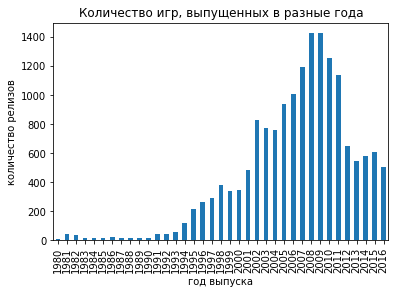

```python
data_games.groupby('year_of_release')['name'].count().plot.bar()

plt.title("Количество игр, выпущенных в разные года")
plt.xlabel("год выпуска")
plt.ylabel("количество релизов")
```

По графику видно, что активный выпуск игр начался с 2001 года. До этого число релизов было кратно меньше.

##### Посмотрите, как менялись продажи по платформам. Выберите платформы с наибольшими суммарными продажами и постройте распределение по годам. За какой характерный срок появляются новые и исчезают старые платформы?

```python
# выберем платформы с наибольшими суммарными продажами

data_games.groupby('platform')['total_sales'].sum().sort_values(ascending=False).head(10)
```

```
platform
ps2     1233.56
x360     961.24
ps3      931.33
wii      891.18
ds       802.78
ps       727.58
ps4      314.14
gba      312.88
psp      289.53
3ds      257.81
Name: total_sales, dtype: float64
```

Оставим 5 самых продаваемых платформ за все года. Построим графики распределения по годам. Года оставим с 2000.

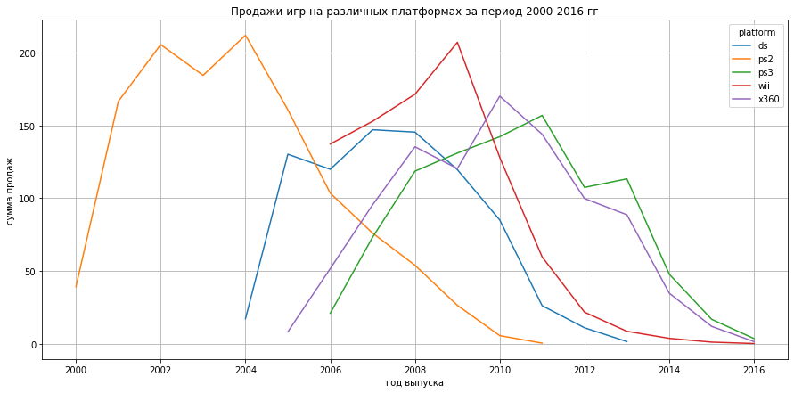

```python
# оставим в выгрузке только нужные года

data_clean = data_games.query("year_of_release >= 1999")

# оставим только 6 самых продаваемых платформ

data_clean = data_clean.query("platform == ['ps2', 'x360', 'ps3', 'wii', 'ds']")

# построим график распределения по годам
data_clean.pivot_table(index='year_of_release', columns = 'platform', values='total_sales', aggfunc='sum').plot(grid=True, figsize=(15, 7))

plt.title("Продажи игр на различных платформах за период 2000-2016 гг")
plt.xlabel("год выпуска")
plt.ylabel("сумма продаж")


plt.show()
```

Пять самых продаваемых платформ были выпущены в период с 2000 по 2006 год. То есть в среднем, новые платформы появлялись ежегодно. Средний срок жизни платформы судя по графику - примерно 10 лет. Исчезновение старых платформ так же прошло примерно в один и тот же срок с 2011 по 2016 года.

##### Какие платформы лидируют по продажам, растут или падают? Выберите несколько потенциально прибыльных платформ.

Возьмите данные за соответствующий актуальный период. Актуальный период определите самостоятельно в результате исследования предыдущих вопросов. Основной фактор — эти данные помогут построить прогноз на 2017 год. Не учитывайте в работе данные за предыдущие годы.

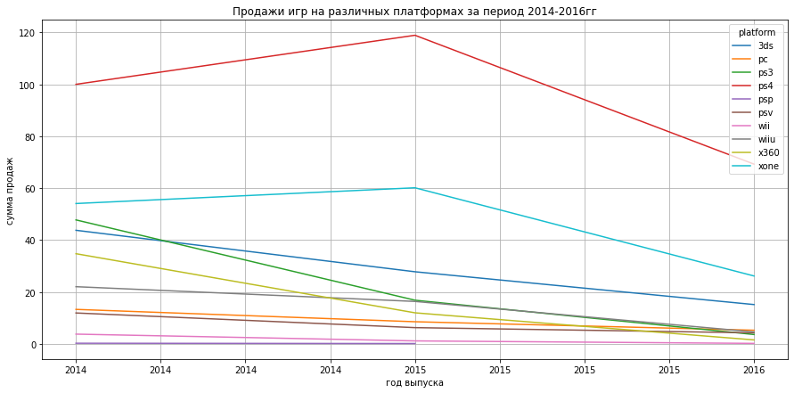

```python
# оставим в выгрузке только послудние два  года

data_clean = data_games.query("year_of_release >= 2014")


# построим график распределения по годам
ax = data_clean.pivot_table(index='year_of_release', columns = 'platform', values='total_sales', aggfunc='sum').plot(grid=True,figsize=(15, 7))

import matplotlib.ticker
formatter = matplotlib.ticker.FormatStrFormatter('%d')

ax.xaxis.set_major_formatter(formatter)


plt.title("Продажи игр на различных платформах за период 2014-2016гг")
plt.xlabel("год выпуска")
plt.ylabel("сумма продаж")



plt.show()
```

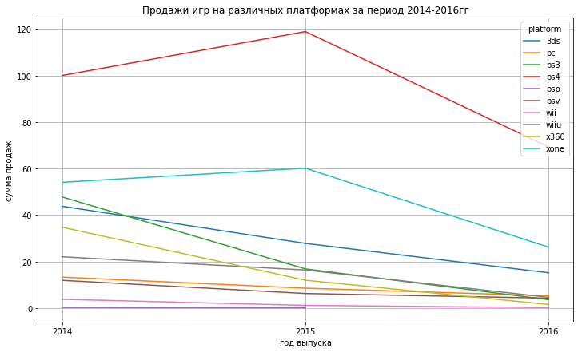

```python
# оставим в выгрузке только послудние два  года

data_clean = data_games.query("year_of_release >= 2014")


# построим график распределения по годам
ax = (data_clean.pivot_table(index='year_of_release', columns = 'platform', values='total_sales', aggfunc='sum')
            .plot(grid=True,figsize=(12, 7)))

import numpy as np
plt.xticks(np.arange(2014, 2017, 1))


plt.title("Продажи игр на различных платформах за период 2014-2016гг")
plt.xlabel("год выпуска")
plt.ylabel("сумма продаж")



plt.show()
```

Мы видим двух сильнейших игроков рынка это платформы ps4 и xone. На убыль идет 3ds. Остальные платформы находятся в одном диапазоне.

##### Постройте график «ящик с усами» по глобальным продажам игр в разбивке по платформам. Опишите результат.

```python
data_clean[data_clean['platform']== 'ps4']['total_sales'].describe()
```

```
count    376.000000
mean       0.766356
std        1.614969
min        0.010000
25%        0.057500
50%        0.185000
75%        0.690000
max       14.630000
Name: total_sales, dtype: float64
```

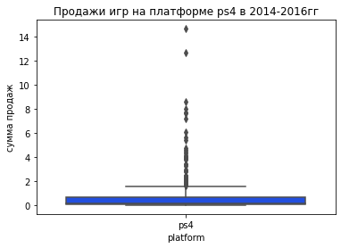

```python
sns.boxplot(
    x='platform',
    y='total_sales',
    data=data_clean[data_clean['platform']== 'ps4'],
    palette='bright')

plt.title("Продажи игр на платформе ps4 в 2014-2016гг")
plt.ylabel("сумма продаж")
```

```python
data_clean[data_clean['platform']== 'ps4']['total_sales'].median()
```

```
0.185
```

```python
# посчитаем количесто исключений

data_clean[(data_clean['platform']== 'ps4') & (data_clean['total_sales'] > 2)]['total_sales'].count()
```

```
39
```

Вывод по продажам платформы ps4 в 2014-2016гг:

- Было выпущено 376 игр, но большая часть из них продавалась на низком уровне
- 39 игр принесли основной доход платформе с более высокими продажами
- средний показатель продаж платформы 0.185
- максимальный ~15

```python
data_clean[data_clean['platform']== 'xone']['total_sales'].describe()
```

```
count    228.000000
mean       0.615614
std        1.046513
min        0.010000
25%        0.050000
50%        0.205000
75%        0.632500
max        7.390000
Name: total_sales, dtype: float64
```

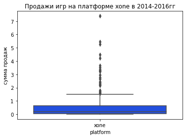

```python
sns.boxplot(
    x='platform',
    y='total_sales',
    data=data_clean[data_clean['platform']== 'xone'],
    palette='bright')

plt.title("Продажи игр на платформе xone в 2014-2016гг")
plt.ylabel("сумма продаж")
```

```python
data_clean[data_clean['platform']== 'xone']['total_sales'].median()
```

```
0.205
```

```python
# посчитаем количесто исключений

data_clean[(data_clean['platform']== 'xone') & (data_clean['total_sales'] > 1.5)]['total_sales'].count()
```

```
25
```

Вывод по продажам платформы xone в 2014-2016гг:

- Было выпущено 228 игр, но большая часть из них продавалась на низком уровне
- 25 игр принесли основной доход платформес более высокими продажами
- средний показатель продаж платформы 0.205
- максимальный ~8

```python
data_clean[data_clean['platform']== '3ds']['total_sales'].describe()
```

```
count    212.000000
mean       0.408868
std        1.188368
min        0.010000
25%        0.030000
50%        0.090000
75%        0.250000
max       11.680000
Name: total_sales, dtype: float64
```

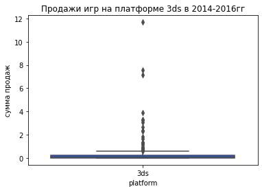

```python
sns.boxplot(
    x='platform',
    y='total_sales',
    data=data_clean[data_clean['platform']== '3ds'],
    palette='bright')

plt.title("Продажи игр на платформе 3ds в 2014-2016гг")
plt.ylabel("сумма продаж")
```

```python
data_clean[data_clean['platform']== '3ds']['total_sales'].median()
```

```
0.09
```

```python
# посчитаем количесто исключений

data_clean[(data_clean['platform']== '3ds') & (data_clean['total_sales'] > 1)]['total_sales'].count()
```

```
16
```

Вывод по продажам платформы 3ds в 2014-2016гг:

- Было выпущено 212 игр, но большая часть из них продавалась на низком уровне
- 16 игр принесли основной доход платформе с более высокими продажами
- средний показатель продаж платформы 0.09
- максимальный ~12

```python
data_clean[data_clean['platform']== 'pc']['total_sales'].describe()
```

```
count    151.000000
mean       0.179139
std        0.329359
min        0.010000
25%        0.020000
50%        0.060000
75%        0.200000
max        3.050000
Name: total_sales, dtype: float64
```

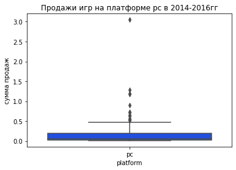

```python
sns.boxplot(
    x='platform',
    y='total_sales',
    data=data_clean[data_clean['platform']== 'pc'],
    palette='bright')

plt.title("Продажи игр на платформе pc в 2014-2016гг")
plt.ylabel("сумма продаж")
```

```python
data_clean[data_clean['platform']== 'pc']['total_sales'].median()
```

```
0.06
```

```python
# посчитаем количесто исключений

data_clean[(data_clean['platform']== 'pc') & (data_clean['total_sales'] > 0.6)]['total_sales'].count()
```

```
9
```

Вывод по продажам платформы pc в 2014-2016гг:

- Было выпущено 151 игра, но большая часть из них продавалась на низком уровне
- 9 игр принесли основной доход платформе с более высокими продажами
- средний показатель продаж платформы 0.06
- максимальный ~3

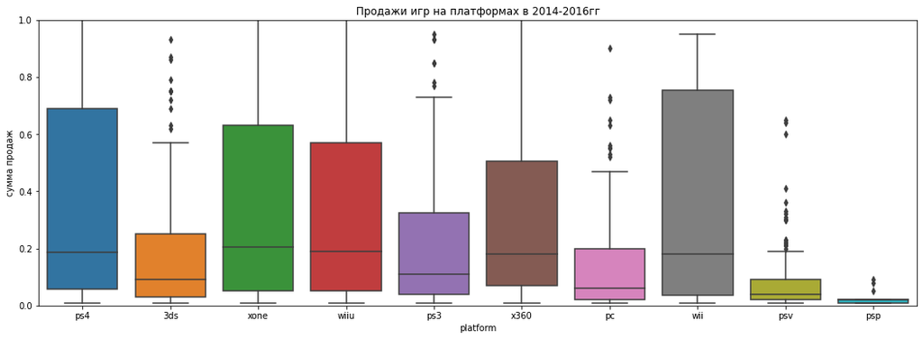

```python
fig, axes = plt.subplots(1, figsize = (18,6))

sns.boxplot(x='platform', y='total_sales', data=data_clean)

plt.ylim(0, 1)

plt.title("Продажи игр на платформах в 2014-2016гг")
plt.ylabel("сумма продаж")
```

Медианы продаж платформ ps4, xone, wii и wiiu почти равны. При этом верхний квартиль wii выше остальных. Это значит, что в среднем продажи wii выше даже при почти равных медианных значениях с ближайшими конкурентами. На втором месте ps4, третьем месте xone.

##### Посмотрите, как влияют на продажи внутри одной популярной платформы отзывы пользователей и критиков. Постройте диаграмму рассеяния и посчитайте корреляцию между отзывами и продажами. Сформулируйте выводы.

```python
data_ps4 = data_clean[data_clean['platform']== 'ps4']

data_ps4.head()
```

|  | name | platform | year_of_release | genre | na_sales | eu_sales | jp_sales | other_sales | critic_score | user_score | rating | total_sales |
| --- | --- | --- | --- | --- | --- | --- | --- | --- | --- | --- | --- | --- |
| 31 | call of duty: black ops 3 | ps4 | 2015 | shooter | 6.03 | 5.86 | 0.36 | 2.38 | NaN | NaN | RP | 14.63 |
| 42 | grand theft auto v | ps4 | 2014 | action | 3.96 | 6.31 | 0.38 | 1.97 | 97.0 | 8.3 | M | 12.62 |
| 77 | fifa 16 | ps4 | 2015 | sports | 1.12 | 6.12 | 0.06 | 1.28 | 82.0 | 4.3 | E | 8.58 |
| 87 | star wars battlefront (2015) | ps4 | 2015 | shooter | 2.99 | 3.49 | 0.22 | 1.28 | NaN | NaN | RP | 7.98 |
| 92 | call of duty: advanced warfare | ps4 | 2014 | shooter | 2.81 | 3.48 | 0.14 | 1.23 | 83.0 | 5.7 | M | 7.66 |

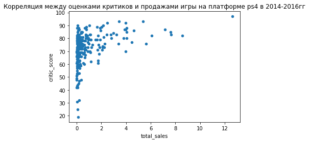

```python
# построим диаграмму рассеяния по двум столбцам

data_ps4.plot.scatter (x = 'total_sales', y = 'critic_score')

plt.title("Корреляция между оценками критиков и продажами игры на платформе ps4 в 2014-2016гг")
```

```python
# найдем численную корреляцию

round(data_ps4['critic_score'].corr(data_ps4['total_sales']), 2)
```

```
0.4
```

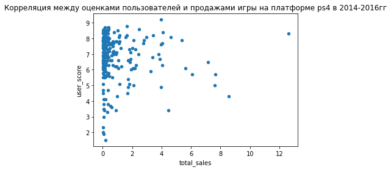

```python
data_ps4.plot.scatter (x = 'total_sales', y = 'user_score')

plt.title("Корреляция между оценками пользователей и продажами игры на платформе ps4 в 2014-2016гг")
```

```python
# найдем корреляцию

round(data_ps4['user_score'].corr(data_ps4['total_sales']),2)
```

```
-0.04
```

Выводы:

- Корреляция между оценками критиков и продажами есть, но довольно слабая = 0.4. В основном критики ставят высокие оценки даже играм, которые показывают низкие продажи.
- Корреляция между оценками пользователей и продажами практически отсутствует = - 0.04. В основном пользователм ставят высокие оценки играм, но могут поставить низкие и играм, с высоким уровнем продаж.

##### Соотнесите выводы с продажами игр на других платформах.

Построим похожие диаграммы для двух других популярных платформ.

Рассмотрим сначала платформу xone.

```python
data_xone = data_clean[data_clean['platform']== 'xone']

data_xone.head()
```

|  | name | platform | year_of_release | genre | na_sales | eu_sales | jp_sales | other_sales | critic_score | user_score | rating | total_sales |
| --- | --- | --- | --- | --- | --- | --- | --- | --- | --- | --- | --- | --- |
| 99 | call of duty: black ops 3 | xone | 2015 | shooter | 4.59 | 2.11 | 0.01 | 0.68 | NaN | NaN | RP | 7.39 |
| 165 | grand theft auto v | xone | 2014 | action | 2.81 | 2.19 | 0.00 | 0.47 | 97.0 | 7.9 | M | 5.47 |
| 179 | call of duty: advanced warfare | xone | 2014 | shooter | 3.22 | 1.55 | 0.01 | 0.48 | 81.0 | 5.4 | M | 5.26 |
| 242 | halo 5: guardians | xone | 2015 | shooter | 2.78 | 1.27 | 0.03 | 0.41 | 84.0 | 6.4 | T | 4.49 |
| 270 | fallout 4 | xone | 2015 | role-playing | 2.51 | 1.32 | 0.01 | 0.38 | 88.0 | 6.2 | M | 4.22 |

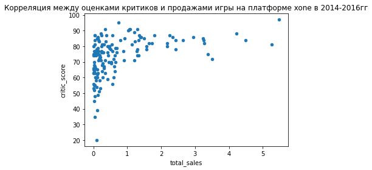

```python
data_xone.plot.scatter (x = 'total_sales', y = 'critic_score')

plt.title("Корреляция между оценками критиков и продажами игры на платформе xone в 2014-2016гг")
```

```python
# найдем численную корреляцию

round(data_xone['critic_score'].corr(data_xone['total_sales']), 2)
```

```
0.43
```

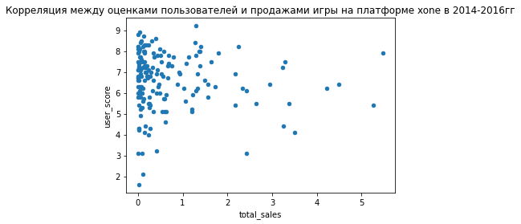

```python
data_xone.plot.scatter (x = 'total_sales', y = 'user_score')

plt.title("Корреляция между оценками пользователей и продажами игры на платформе xone в 2014-2016гг")
```

```python
# найдем корреляцию

round(data_xone['user_score'].corr(data_xone['total_sales']), 2)
```

```
-0.07
```

Второй рассмотрим платформу 3ds.

```python
data_3ds = data_clean[data_clean['platform']== '3ds']

data_3ds.head()
```

|  | name | platform | year_of_release | genre | na_sales | eu_sales | jp_sales | other_sales | critic_score | user_score | rating | total_sales |
| --- | --- | --- | --- | --- | --- | --- | --- | --- | --- | --- | --- | --- |
| 47 | pokemon omega ruby/pokemon alpha sapphire | 3ds | 2014 | role-playing | 4.35 | 3.49 | 3.10 | 0.74 | NaN | NaN | RP | 11.68 |
| 96 | super smash bros. for wii u and 3ds | 3ds | 2014 | fighting | 3.27 | 1.37 | 2.43 | 0.48 | NaN | NaN | RP | 7.55 |
| 108 | pokemon sun/moon | 3ds | 2016 | role-playing | 2.98 | 1.45 | 2.26 | 0.45 | NaN | NaN | RP | 7.14 |
| 312 | monster hunter 4 ultimate | 3ds | 2014 | role-playing | 0.68 | 0.48 | 2.62 | 0.11 | 86.0 | 8.7 | T | 3.89 |
| 406 | monster hunter x | 3ds | 2015 | action | 0.27 | 0.21 | 2.79 | 0.05 | NaN | NaN | RP | 3.32 |

[figure not shown]

```python
data_3ds.plot.scatter (x = 'total_sales', y = 'critic_score')

plt.title("Корреляция между оценками критиков и продажами игры на платформе xone в 2014-2016гг")
```

```python
round(data_3ds['critic_score'].corr(data_3ds['total_sales']), 2)
```

```
0.31
```

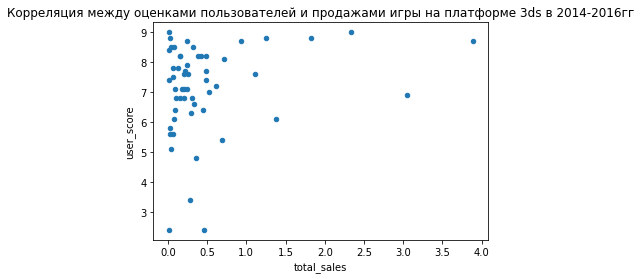

```python
data_3ds.plot.scatter (x = 'total_sales', y = 'user_score')

plt.title("Корреляция между оценками пользователей и продажами игры на платформе 3ds в 2014-2016гг")
```

```python
round(data_3ds['user_score'].corr(data_3ds['total_sales']), 2)
```

```
0.22
```

##### Посмотрите на общее распределение игр по жанрам. Что можно сказать о самых прибыльных жанрах? Выделяются ли жанры с высокими и низкими продажами?

Рассмотрим популярные жанры игр с 2014 года. Сгруппируем данные по жанрам игр и посчитаем их продажи.

```python
# воспользуемся датафреймом, который хранит данные только с 2014 года и позже

data_clean.head()
```

|  | name | platform | year_of_release | genre | na_sales | eu_sales | jp_sales | other_sales | critic_score | user_score | rating | total_sales |
| --- | --- | --- | --- | --- | --- | --- | --- | --- | --- | --- | --- | --- |
| 31 | call of duty: black ops 3 | ps4 | 2015 | shooter | 6.03 | 5.86 | 0.36 | 2.38 | NaN | NaN | RP | 14.63 |
| 42 | grand theft auto v | ps4 | 2014 | action | 3.96 | 6.31 | 0.38 | 1.97 | 97.0 | 8.3 | M | 12.62 |
| 47 | pokemon omega ruby/pokemon alpha sapphire | 3ds | 2014 | role-playing | 4.35 | 3.49 | 3.10 | 0.74 | NaN | NaN | RP | 11.68 |
| 77 | fifa 16 | ps4 | 2015 | sports | 1.12 | 6.12 | 0.06 | 1.28 | 82.0 | 4.3 | E | 8.58 |
| 87 | star wars battlefront (2015) | ps4 | 2015 | shooter | 2.99 | 3.49 | 0.22 | 1.28 | NaN | NaN | RP | 7.98 |

```python
# посмотрим какие  у нас есть жанры

data_clean['genre'].unique()
```

```
array(['shooter', 'action', 'role-playing', 'sports', 'fighting',
       'racing', 'misc', 'platform', 'simulation', 'adventure', 'puzzle',
       'strategy'], dtype=object)
```

```python
# посмотрим распределение игр по жанрам

data_clean.groupby('genre')['name'].count().sort_values()
```

```
genre
puzzle           14
strategy         37
platform         38
simulation       44
fighting         60
racing           69
misc            113
shooter         128
sports          161
adventure       185
role-playing    221
action          619
Name: name, dtype: int64
```

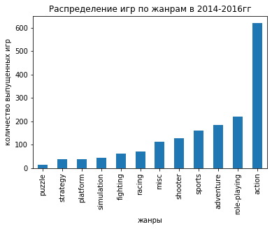

```python
# визуализиурем

data_clean.groupby('genre')['name'].count().sort_values().plot.bar()

plt.title("Распределение игр по жанрам в 2014-2016гг")
plt.xlabel("жанры")
plt.ylabel("количество выпущенных игр")
```

```python
# посмотрим распределение доход по жанрам

data_clean.groupby('genre')['total_sales'].sum().sort_values()
```

```
genre
puzzle            2.21
strategy          3.96
simulation       13.13
adventure        17.55
platform         18.09
racing           27.52
fighting         28.22
misc             37.55
role-playing    101.44
sports          109.48
shooter         170.94
action          199.36
Name: total_sales, dtype: float64
```

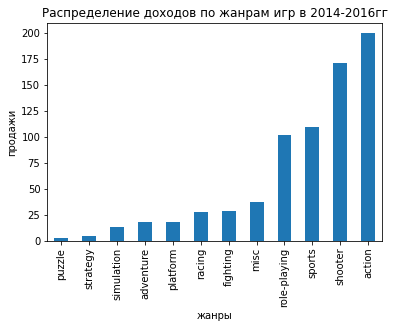

```python
# визуализиурем

data_clean.groupby('genre')['total_sales'].sum().sort_values().plot.bar()

plt.title("Распределение доходов по жанрам игр в 2014-2016гг")
plt.xlabel("жанры")
plt.ylabel("продажи")
```

Построим диаграмму размаха продаж игр в разных жанрах за 2014-2016гг.

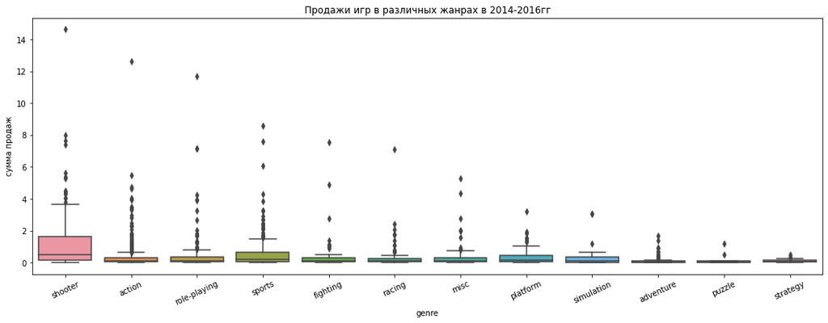

```python
fig, axes = plt.subplots(1, figsize = (18,6))
sns.boxplot(x='genre', y='total_sales', data=data_clean)

plt.xticks(rotation = 25)
plt.title("Продажи игр в различных жанрах в 2014-2016гг")
plt.ylabel("сумма продаж")
```

Построим такой же график без выбросов.

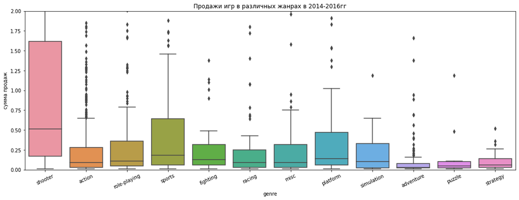

```python
fig, axes = plt.subplots(1, figsize = (18,6))

sns.boxplot(x='genre', y='total_sales', data=data_clean)

plt.ylim(0, 2)
plt.xticks(rotation = 25)
plt.title("Продажи игр в различных жанрах в 2014-2016гг")
plt.ylabel("сумма продаж")
```

Выводы о жанрах игр и их продажах в 2014-2016 году:

- самые продаваемые жанры - action, shooter, sports, role-playing
- самые часто выпускаемые игры - action, adventure, sports, role-playing, misc, shooter. При этом misc и adventure принесли в разы меньше денег, чем топовые жанры из предыдущего пункта.
- самые не популярные жанры - puzzle и strategy
- самые устойчивые продажи показывают игры в жанре shooter, на втором месте sports, на третьем - platform

Общий вывод Шага 3:

Согласно нашим данным активный выпуск игр начался с 2001 года. До этого число релизов было кратно меньше.

Пять самых продаваемых платформ за представленный период были выпущены с 2000 по 2006 год. То есть в среднем, новые платформы появлялись ежегодно. Средний срок жизни платформы судя по графику - примерно 10 лет. Исчезновение старых платформ так же произошло примерно в один и тот же срок с 2011 по 2016 года.

В последние три года (2014-2016гг) мы видим двух сильнейших игроков рынка - это платформы ps4 и xone. На убыль идет 3ds. Остальные платформы находятся в одном диапазоне с более низкими сборами относительно лидеров.

Мы рассмотрели продажи отдельно каждой платформы-лидера.

Вывод по продажам платформы ps4 в 2014-2016гг:

- Было выпущено 376 игр, но большая часть из них продавалась на низком уровне
- 39 игр принесли основной доход платформе с более высокими продажами
- средний показатель продаж платформы 0.185
- максимальный ~15

Вывод по продажам платформы xone в 2014-2016гг:

- Было выпущено 228 игр, но большая часть из них продавалась на низком уровне
- 25 игр принесли основной доход платформес более высокими продажами
- средний показатель продаж платформы 0.205
- максимальный ~8

Вывод по продажам платформы 3ds в 2014-2016гг:

- Было выпущено 212 игр, но большая часть из них продавалась на низком уровне
- 16 игр принесли основной доход платформе с более высокими продажами
- средний показатель продаж платформы 0.09
- максимальный ~12

Вывод по продажам платформы pc в 2014-2016гг:

- Было выпущено 151 игра, но большая часть из них продавалась на низком уровне
- 9 игр принесли основной доход платформе с более высокими продажами
- средний показатель продаж платформы 0.06
- максимальный ~3

Медианы продаж платформ ps4, xone, wii и wiiu почти равны. При этом верхний квартиль wii выше остальных. Это значит, что в среднем продажи wii выше даже при почти равных медианных значениях с ближайшими конкурентами. На втором месте ps4, третьем месте xone.

В основном критики ставят высокие оценки даже играм, которые показывают низкие продажи.

Корреляция между оценками пользователей и продажами практически отсутствует. В основном пользователм ставят высокие оценки играм, но могут поставить низкие и играм, с высоким уровнем продаж.

Выводы о жанрах игр и их продажах в 2014-2016 году:

- самые продаваемые жанры - action, shooter, sports, role-playing
- самые часто выпускаемые игры - action, adventure, sports, role-playing, misc, shooter. При этом misc и adventure принесли в разы меньше денег, чем топовые жанры из предыдущего пункта.
- самые не популярные жанры - puzzle и strategy
- самые устойчивые продажи показывают игры в жанре shooter, на втором месте sports, на третьем - platform

#### Шаг 4. Составьте портрет пользователя каждого региона.

Определите для пользователя каждого региона (NA, EU, JP):

##### Самые популярные платформы (топ-5). Опишите различия в долях продаж.

```python
data_clean.head()
```

|  | name | platform | year_of_release | genre | na_sales | eu_sales | jp_sales | other_sales | critic_score | user_score | rating | total_sales |
| --- | --- | --- | --- | --- | --- | --- | --- | --- | --- | --- | --- | --- |
| 31 | call of duty: black ops 3 | ps4 | 2015 | shooter | 6.03 | 5.86 | 0.36 | 2.38 | NaN | NaN | RP | 14.63 |
| 42 | grand theft auto v | ps4 | 2014 | action | 3.96 | 6.31 | 0.38 | 1.97 | 97.0 | 8.3 | M | 12.62 |
| 47 | pokemon omega ruby/pokemon alpha sapphire | 3ds | 2014 | role-playing | 4.35 | 3.49 | 3.10 | 0.74 | NaN | NaN | RP | 11.68 |
| 77 | fifa 16 | ps4 | 2015 | sports | 1.12 | 6.12 | 0.06 | 1.28 | 82.0 | 4.3 | E | 8.58 |
| 87 | star wars battlefront (2015) | ps4 | 2015 | shooter | 2.99 | 3.49 | 0.22 | 1.28 | NaN | NaN | RP | 7.98 |

```python
# посмотрим сколько всего у нас платформ осталось за выделенный период  2014-2016гг

data_clean['platform'].unique()
```

```
array(['ps4', '3ds', 'xone', 'wiiu', 'ps3', 'x360', 'pc', 'wii', 'psv',
       'psp'], dtype=object)
```

```python
# воспользуемся данными за 2014-2016 гг, отсортируем продажи по платформам

data_clean.groupby('platform')['total_sales'].sum().sort_values(ascending = False)
```

```
platform
ps4     288.15
xone    140.36
3ds      86.68
ps3      68.18
x360     48.22
wiiu     42.98
pc       27.05
psv      22.40
wii       5.07
psp       0.36
Name: total_sales, dtype: float64
```

```python
# выведем данные о суммированных продажах в разных регионах платформ за 2014-2016 года

data_clean_by_region_sales = data_clean.pivot_table(
    index= 'platform',  values=['na_sales', 'eu_sales', 'jp_sales', 'other_sales', 'total_sales'] , aggfunc= 'sum'
)

data_clean_by_region_sales.head(10)
```

| platform | eu_sales | jp_sales | na_sales | other_sales | total_sales |
| --- | --- | --- | --- | --- | --- |
| 3ds | 16.12 | 44.24 | 22.64 | 3.68 | 86.68 |
| pc | 17.97 | 0.00 | 7.23 | 1.85 | 27.05 |
| ps3 | 25.54 | 11.22 | 22.05 | 9.37 | 68.18 |
| ps4 | 130.04 | 15.02 | 98.61 | 44.48 | 288.15 |
| psp | 0.00 | 0.36 | 0.00 | 0.00 | 0.36 |
| psv | 3.53 | 14.54 | 2.52 | 1.81 | 22.40 |
| wii | 2.59 | 0.00 | 2.08 | 0.40 | 5.07 |
| wiiu | 13.15 | 7.31 | 19.36 | 3.16 | 42.98 |
| x360 | 15.49 | 0.08 | 28.30 | 4.35 | 48.22 |
| xone | 46.25 | 0.32 | 81.27 | 12.52 | 140.36 |

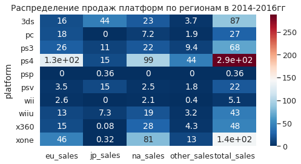

```python
# визуализируем общие данные

sns.set(font_scale=1.15)
plt.figure(figsize=(8,4))
sns.heatmap(
    data_clean_by_region_sales,
    cmap='RdBu_r',
    annot=True,
)

plt.title("Распределение продаж платформ по регионам в 2014-2016гг")
```

Визуализируем данные по каждому региону отдельно.

```python
# check
# круги + категория другие
def graph (df, year, region, name, axes):

    df = df.query('year_of_release >= @year')

    sales = df.pivot_table(index='platform',
                           values=region,
                           aggfunc='sum').nlargest(5, region)

    sales = sales.reset_index()

    sales = (
            sales.append({'platform': 'other', region: df[region].sum()
                       - sales[region].sum()}, ignore_index= True)
         )


    sales.columns = ['platform', 'sales']

    labels_c=sales.platform
    colours = {'wii':'C0', 'nes':'C1', 'gb':'C2', 'ds':'C3', 'x360':'C4',
    'ps3':'C5', 'ps2':'C6', 'snes':'C7', 'gba':'C8',
               'ps4':'steelblue', '3ds':'orange',
               'n64':'C11', 'ps':'C12', 'xb':'C13', 'pc':'C14', '2600':'C15', 'psp':'C16',
               'xone':'C17',
               'wiiu':'C18', 'gc':'C19', 'gen':'C20', 'dc':'C21', 'psv':'C22',
               'sat':'C23', 'scd':'C24', 'ws':'C25', 'ng':'C26',
               'tg16':'C27', '3do':'C28', 'gg':'C29', 'pcfx':'C30', 'other':'darkred'}

    sales.plot(kind='pie',
               y="sales",

               autopct='%1.0f%%',
               wedgeprops={'linewidth': 3.0, 'edgecolor': 'white'},
               textprops={'size': 'x-large'},
               labels= labels_c,
               colors=[colours[key] for key in labels_c],
               legend=False,
               title = f"Популярность платформ в {name} ",
               ax = axes).set(ylabel='')

    plt.tight_layout()
```

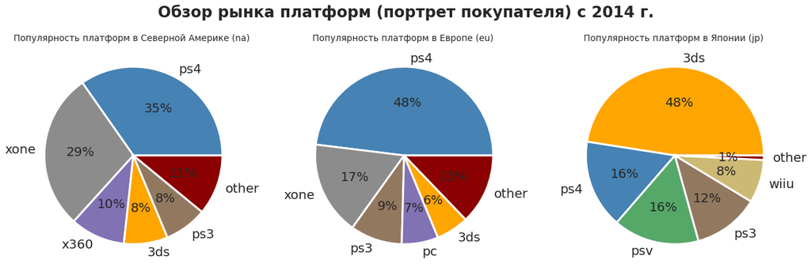

```python
# check
# круги в ряд

x_year = 2014

fig, axes = plt.subplots(1, 3, figsize = (18,6))
fig.suptitle(f'Обзор рынка платформ (портрет покупателя) с {x_year} г.', fontsize = 24, fontweight='bold')

graph(data_games, x_year, 'na_sales', 'Северной Америке (na)', axes[0])
graph(data_games, x_year,'eu_sales', 'Европе (eu)', axes[1])
graph(data_games, x_year, 'jp_sales', 'Японии (jp)', axes[2])
```

Выводы распределения ТОП-5 популярных платформ по рынкам продаж:

- самые крупные рынки это eu и na
- лидер среди платформ по продажам ps4 занимает лидирующее положение во всех регионах, кроме jp, где его обходит 3ds
- лидеры рынка eu - ps4 (48%), xone (17%), ps3 (9%)
- лидеры рынка jp - 3ds (48%), ps4 (16%), psv (16%)
- лидеры рынка na - ps4 (35%), xone (29%), x360 (10%)

##### Самые популярные жанры (топ-5). Поясните разницу.

Ранее мы уже выбирали 5 жанров самых продаваемых игр. К ним относятся action, shooter, sports, role-playing, misc.

Рассмотрим распределение жанров игр по регионам.

```python
# сначала выделим отдельный дата фрейм только с жанрами, что нас интересуют

data_clean['genre'].unique()
```

```
array(['shooter', 'action', 'role-playing', 'sports', 'fighting',
       'racing', 'misc', 'platform', 'simulation', 'adventure', 'puzzle',
       'strategy'], dtype=object)
```

```python
# выведем данные о суммированных продажах в разных регионах ТОП-5 жанров игр за 2014-2016 года

data_clean_by_genre_sales = data_clean.pivot_table(
    index= 'genre',  values=['na_sales', 'eu_sales', 'jp_sales', 'other_sales', 'total_sales'] , aggfunc= 'sum'
)

data_clean_by_genre_sales.head(20)
```

| genre | eu_sales | jp_sales | na_sales | other_sales | total_sales |
| --- | --- | --- | --- | --- | --- |
| action | 74.68 | 29.58 | 72.53 | 22.57 | 199.36 |
| adventure | 6.49 | 3.60 | 5.64 | 1.82 | 17.55 |
| fighting | 6.69 | 6.37 | 12.43 | 2.73 | 28.22 |
| misc | 12.86 | 5.61 | 15.05 | 4.03 | 37.55 |
| platform | 6.80 | 2.69 | 6.79 | 1.81 | 18.09 |
| puzzle | 0.52 | 0.93 | 0.65 | 0.11 | 2.21 |
| racing | 14.13 | 1.76 | 8.74 | 2.89 | 27.52 |
| role-playing | 28.17 | 31.16 | 33.47 | 8.64 | 101.44 |
| shooter | 65.52 | 4.87 | 79.02 | 21.53 | 170.94 |
| simulation | 7.30 | 2.31 | 2.63 | 0.89 | 13.13 |
| sports | 45.73 | 3.26 | 46.13 | 14.36 | 109.48 |
| strategy | 1.79 | 0.95 | 0.98 | 0.24 | 3.96 |

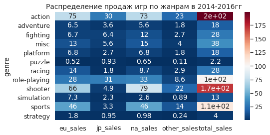

```python
# визуализируем общие данные

sns.set(font_scale=1.15)
plt.figure(figsize=(8,4))
sns.heatmap(
    data_clean_by_genre_sales,
    cmap='RdBu_r',
    annot=True,
)

plt.title("Распределение продаж игр по жанрам в 2014-2016гг")
```

Визуализируем данные по каждому региону отдельно.

```python
# check
# круги + категория другие
def graph_genre(df, year, region, name, axes):

    df = df.query('year_of_release >= @year')

    sales = df.pivot_table(index='genre',
                           values=region,
                           aggfunc='sum').nlargest(5, region)

    sales = sales.reset_index()

    sales = (
            sales.append({'genre': 'other', region: df[region].sum()
                       - sales[region].sum()}, ignore_index= True)
         )


    sales.columns = ['genre', 'sales']

    labels_c=sales.genre
    colours = {'action':'C0', 'adventure':'C1', 'fighting':'C2', 'misc':'C3', 'platform':'C4',
    'puzzle':'C5', 'racing':'C6', 'role-playing':'C7', 'shooter':'C8',
               'simulation':'steelblue', 'sports':'orange',
               'strategy':'C11', 'other':'darkred'}

    sales.plot(kind='pie',
               y="sales",

               autopct='%1.0f%%',
               wedgeprops={'linewidth': 3.0, 'edgecolor': 'white'},
               textprops={'size': 'x-large'},
               labels= labels_c,
               colors=[colours[key] for key in labels_c],
               legend=False,
               title = f"Популярность жанров игр в {name} ",
               ax = axes).set(ylabel='')

    plt.tight_layout()
```

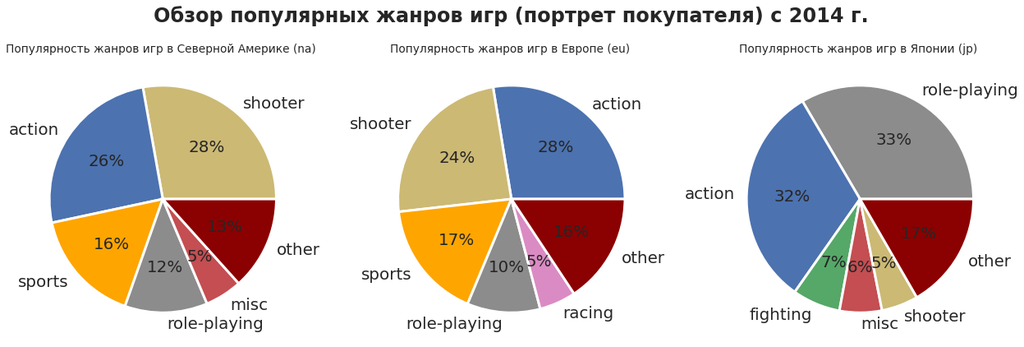

```python
# check
# круги в ряд

x_year = 2014

fig, axes = plt.subplots(1, 3, figsize = (18,6))
fig.suptitle(f'Обзор популярных жанров игр (портрет покупателя) с {x_year} г.', fontsize = 24, fontweight='bold')

graph_genre(data_games, x_year, 'na_sales', 'Северной Америке (na)', axes[0])
graph_genre(data_games, x_year,'eu_sales', 'Европе (eu)', axes[1])
graph_genre(data_games, x_year, 'jp_sales', 'Японии (jp)', axes[2])
```

Выводы распределения ТОП-5 популярных жанров игр по регионам продаж:

- лидеры рынка eu - action (28%), shooter (24%), sports (17%)
- лидеры рынка jp - role-playing (33%), action (32%), fighting (7%)
- лидеры рынка na - shooter (28%), action (26%), sports (16%)

##### Влияет ли рейтинг ESRB на продажи в отдельном регионе?

Рассмотрим влияние в каждом регионе рейтинга ESRB на продажи. Начнем с региона eu.

```python
# посмотрим в каких жанрах у нас выходили  игры в 2014-2016 годах

data_clean['rating'].unique()
```

```
array(['RP', 'M', 'E', 'T', 'E10+'], dtype=object)
```

```python
# выведем данные о суммированных продажах в разных регионах игр согласно рейтингу ESRB  за 2014-2016 года

data_clean_by_rating_sales = data_clean.pivot_table(
    index= 'rating',  values=['na_sales', 'eu_sales', 'jp_sales', 'other_sales'] , aggfunc= 'sum'
)

data_clean_by_rating_sales.head()
```

| rating | eu_sales | jp_sales | na_sales | other_sales |
| --- | --- | --- | --- | --- |
| E | 58.06 | 8.94 | 50.74 | 15.39 |
| E10+ | 26.16 | 4.46 | 33.23 | 7.83 |
| M | 93.44 | 8.01 | 96.42 | 28.67 |
| RP | 58.95 | 56.90 | 64.72 | 18.40 |
| T | 34.07 | 14.78 | 38.95 | 11.33 |

[figure not shown]

```python
data_clean_by_rating_sales.plot.barh()

plt.title("Распределение продаж ТОП-5 самых продаваемых жанров игр в регионе other в 2014-2016гг")
plt.xlabel("число продаж")
plt.ylabel("категория в ретинге ESRB")
```

Напомним значение аббервиатур по возрастам:

Т - тинейджеры, возраст 17+ RP - рейтинг ожидается (не присвоен) М - взрослые, 18+ Е10+ - дети старше 10 лет Е - для всех возрастов

Распределение на рынках eu, na, other примерно похоже. Самые популярные игры здесь в категории М, далее идут по убыванию RP, E, T, E10+

Ны рынке jp самые популярные игры находятся в категории RP, далее по убыванию T, E, M, E 10+.

Общий вывод шага 4:

Выводы распределения ТОП-5 популярных платформ по рынкам продаж:

- самые крупные рынки это eu и na
- лидер среди платформ по продажам ps4 занимает лидирующее положение во всех регионах, кроме jp, где его обходит 3ds
- лидеры рынка eu - ps4 (48%), xone (17%), ps3 (9%)
- лидеры рынка jp - 3ds (48%), ps4 (16%), psv (16%)
- лидеры рынка na - ps4 (35%), xone (29%), x360 (10%)

Выводы распределения ТОП-5 популярных жанров игр по регионам продаж:

- лидеры рынка eu - action (28%), shooter (24%), sports (17%)
- лидеры рынка jp - role-playing (33%), action (32%), fighting (7%)
- лидеры рынка na - shooter (28%), action (26%), sports (16%)

Влияние рейтинга ESRB на продажи игр по регионам:

Распределение на рынках eu, na, other примерно похоже. Самые популярные игры здесь в категории М, далее идут по убыванию RP, E, T, E10+

Ны рынке jp самые популярные игры находятся в категории RP, далее по убыванию T, E, M, E 10+.

Напомним значение аббервиатур по возрастам:

Т - тинейджеры, возраст 17+ RP - рейтинг ожидается (не присвоен) М - взрослые, 18+ Е10+ - дети старше 10 лет Е - для всех возрастов.

#### Шаг 5. Проверьте гипотезы

##### Средние пользовательские рейтинги платформ Xbox One и PC одинаковые

Рассмотрим, какие у нас есть в данных платформы.

```python
data_games[data_games['platform'] == 'xone']['user_score'].describe()
```

```
count    182.000000
mean       6.521429
std        1.380941
min        1.600000
25%        5.800000
50%        6.800000
75%        7.500000
max        9.200000
Name: user_score, dtype: float64
```

```python
# избавимся от значений nan

data_xone = data_games[data_games['platform'] == 'xone']['user_score'].dropna()

data_xone.describe()
```

```
count    182.000000
mean       6.521429
std        1.380941
min        1.600000
25%        5.800000
50%        6.800000
75%        7.500000
max        9.200000
Name: user_score, dtype: float64
```

Платформа PC вышла намного раньше, чем XOne. Поэтому ограничим данные по оценкам платформы PC 2013 годом.

```python
data_pc = data_games.query('year_of_release >= 2013')
```

```python
data_pc[data_pc['platform'] == 'pc']['user_score'].describe()
```

```
count    155.000000
mean       6.269677
std        1.742381
min        1.400000
25%        5.300000
50%        6.800000
75%        7.600000
max        9.300000
Name: user_score, dtype: float64
```

```python
# избавимся от значений nan

data_pc = data_pc[data_pc['platform'] == 'pc']['user_score'].dropna()

data_pc.describe()
```

```
count    155.000000
mean       6.269677
std        1.742381
min        1.400000
25%        5.300000
50%        6.800000
75%        7.600000
max        9.300000
Name: user_score, dtype: float64
```

Проверим гипотезу "Средние пользовательские рейтинги платформ Xbox One и PC одинаковые". Это и будет наша нулевая гипотеза. Альтернативной гипотеза "Средние пользовательские рейтинги платформ Xbox One и PC не одинаковые".

```python
alpha = 0.05 # уровень статистической значимости
# если p-value окажется меньше него, отвергнем гипотезу

sample_1 = data_xone
sample_2 = data_pc

results = st.ttest_ind(sample_1, sample_2)

print('p-значение:', results.pvalue)
print('среднее значение оценок пользователей игр платформы xone:',sample_1.mean())
print('среднее значение оценок пользователей игр платформы pc:', sample_2.mean())

if results.pvalue < alpha:
    print('Не можем подтвердить гипотезу')
else:
    print('Не получилось отвергнуть нулевую гипотезу')
```

```
p-значение: 0.14012658403611647
среднее значение оценок пользователей игр платформы xone: 6.521428571428572
среднее значение оценок пользователей игр платформы pc: 6.2696774193548395
Не получилось отвергнуть нулевую гипотезу
```

##### Средние пользовательские рейтинги жанров Action (англ. «действие», экшен-игры) и Sports (англ. «спортивные соревнования») разные.

```python
data_games[data_games['genre'] == 'action']['user_score'].describe()
```

```
count    1796.000000
mean        7.058129
std         1.423901
min         0.300000
25%         6.300000
50%         7.400000
75%         8.100000
max         9.500000
Name: user_score, dtype: float64
```

```python
# выделим отдельный фрейм с ненулевыми значениями

data_action = data_games[data_games['genre'] == 'action']['user_score'].dropna()
```

```python
data_action.count()
```

```
1796
```

```python
data_action.describe()
```

```
count    1796.000000
mean        7.058129
std         1.423901
min         0.300000
25%         6.300000
50%         7.400000
75%         8.100000
max         9.500000
Name: user_score, dtype: float64
```

```python
# аналогично для жанра sports

data_games[data_games['genre'] == 'sports']['user_score'].describe()
```

```
count    1080.000000
mean        6.952778
std         1.619732
min         0.200000
25%         6.100000
50%         7.400000
75%         8.100000
max         9.500000
Name: user_score, dtype: float64
```

```python
data_sports = data_games[data_games['genre'] == 'sports']['user_score'].dropna()
```

```python
data_sports.count()
```

```
1080
```

```python
data_sports.describe()
```

```
count    1080.000000
mean        6.952778
std         1.619732
min         0.200000
25%         6.100000
50%         7.400000
75%         8.100000
max         9.500000
Name: user_score, dtype: float64
```

Проверим гипотезу "Средние пользовательские рейтинги жанров Action (англ. «действие», экшен-игры) и Sports (англ. «спортивные соревнования») разные".

Наша нулевая гипотеза будет "Средние пользовательские рейтинги жанров Action (англ. «действие», экшен-игры) и Sports (англ. «спортивные соревнования») равны".

Альтернативная гипотеза "Средние пользовательские рейтинги жанров Action (англ. «действие», экшен-игры) и Sports (англ. «спортивные соревнования») не равны".

```python
alpha = 0.05 # уровень статистической значимости
# если p-value окажется меньше него, отвергнем гипотезу

sample_1 = data_action
sample_2 = data_sports

results = st.ttest_ind(sample_1, sample_2)

print('p-значение:', round(results.pvalue, 3))
print('среднее значение оценок пользователей игр жанра action:',sample_1.mean())
print('среднее значение оценок пользователей игр жанра sports:', sample_2.mean())

if results.pvalue < alpha:
    print('Не можем подтвердить нулевую гипотезу')
else:
    print('Не получилось отвергнуть нулевую гипотезу')
```

```
p-значение: 0.068
среднее значение оценок пользователей игр жанра action: 7.058129175946549
среднее значение оценок пользователей игр жанра sports: 6.9527777777777775
Не получилось отвергнуть нулевую гипотезу
```

Выводы шага 5.

- Проверили гипотезу "Средние пользовательские рейтинги платформ Xbox One и PC одинаковые".

- Проверим гипотезу "Средние пользовательские рейтинги жанров Action (англ. «действие», экшен-игры) и Sports (англ. «спортивные соревнования») разные".

#### Шаг 6. Общий вывод.

Вывод Шага 1. Знакомство с данными:

- База содержит данные о 16 713 играх.
- Нулевых значений нет.
- Есть пропущенные значения в столбцах: ** Critic_Score ** User_Score ** Rating ** Year_of_Release ** Name ** Genre
- Наименования столбцов логичные, но написаны с заглавной буквы.
- Тип данных стобца User_Score не соответствует содержанию. Year_of_Release можно сделать типа int.

Вывод шага 2. Предобработка данных:

- Привели наименование столбцов к нижнему регистру
- Привели значения столбцов name, platform, genre к нижнему регистру, чтобы потом исключить дубликаты из-за разного написания
- Удалили строки, где нет данных о годе выпуска игры, тк при дальнейшем анализе для нас это важно. В данном столбце пропуски могли возникнуть из-за невнимательного заполнения данных.
- Сделали столбец year_of_release типа данных int
- Удалили два пропуска в столбце 'name' , тк нам важны наименования игр при дальнейшем анализе. В данном столбце пропуски могли возникнуть из-за невнимательного заполнения данных.
- Оценка 'tbd' - сленговая среди геймеров, не относится к числовому показателю. Убрать строки с этой оценкой - значит потерять часть данных. Чтобы полноценно пользоваться этими данными, сделали эту оценку Nan. Сам столбец user_score перевели в тип данных float.
- Оставили пропуски столбца user_score. Мы не можем их заполнить из-за разнородности данных. В данном столбце пропуски могли возникнуть из-за отсутствия данных.
- Согласно данным из Википедии в разделении на категории Entertainment Software Rating Board, категории Е и К-А - это одно и тоже. Переименовали категорию К-А в Е. Пропуски заполнили значением категории - RP - то есть, "рейтинг ожидается".
- Оставили пропуски столбца critic_score. Мы не можем их заполнить из-за разнородности данных. В данном столбце пропуски могли возникнуть из-за отсутствия данных.
- Проверили данные на отсутствие явных дубликатов.
- Проверили данные на неявные дубликаты по ключевым столбцам, удалили один.
- Итоговые данные составили 98% от исходных.
- Добавили столбец total_sales - общие продажи по всем регионам.

Общий вывод Шага 3. Исследовательский анализ данных::

Согласно нашим данным активный выпуск игр начался с 2001 года. До этого число релизов было кратно меньше.

Пять самых продаваемых платформ за представленный период были выпущены с 2000 по 2006 год. То есть в среднем, новые платформы появлялись ежегодно. Средний срок жизни платформы судя по графику - примерно 10 лет. Исчезновение старых платформ так же произошло примерно в один и тот же срок с 2011 по 2016 года.

В последние три года (2014-2016гг) мы видим двух сильнейших игроков рынка - это платформы ps4 и xone. На убыль идет 3ds. Остальные платформы находятся в одном диапазоне с более низкими сборами относительно лидеров.

Мы рассмотрели продажи отдельно каждой платформы-лидера.

Вывод по продажам платформы ps4 в 2014-2016гг:

- Было выпущено 376 игр, но большая часть из них продавалась на низком уровне
- 39 игр принесли основной доход платформе с более высокими продажами
- средний показатель продаж платформы 0.185
- максимальный ~15

Вывод по продажам платформы xone в 2014-2016гг:

- Было выпущено 228 игр, но большая часть из них продавалась на низком уровне
- 25 игр принесли основной доход платформес более высокими продажами
- средний показатель продаж платформы 0.205
- максимальный ~8

Вывод по продажам платформы 3ds в 2014-2016гг:

- Было выпущено 212 игр, но большая часть из них продавалась на низком уровне
- 16 игр принесли основной доход платформе с более высокими продажами
- средний показатель продаж платформы 0.09
- максимальный ~12

Вывод по продажам платформы pc в 2014-2016гг:

- Было выпущено 151 игра, но большая часть из них продавалась на низком уровне
- 9 игр принесли основной доход платформе с более высокими продажами
- средний показатель продаж платформы 0.06
- максимальный ~3

Медианы продаж платформ ps4, xone, wii и wiiu почти равны. При этом верхний квартиль wii выше остальных. Это значит, что в среднем продажи wii выше даже при почти равных медианных значениях с ближайшими конкурентами. На втором месте ps4, третьем месте xone.

В основном критики ставят высокие оценки даже играм, которые показывают низкие продажи.

Корреляция между оценками пользователей и продажами практически отсутствует. В основном пользователм ставят высокие оценки играм, но могут поставить низкие и играм, с высоким уровнем продаж.

Выводы о жанрах игр и их продажах в 2014-2016 году:

- самые продаваемые жанры - action, shooter, sports, role-playing
- самые часто выпускаемые игры - action, adventure, sports, role-playing, misc, shooter. При этом misc и adventure принесли в разы меньше денег, чем топовые жанры из предыдущего пункта.
- самые не популярные жанры - puzzle и strategy
- самые устойчивые продажи показывают игры в жанре shooter, на втором месте sports, на третьем - platform

Общий вывод шага 4:

Выводы распределения ТОП-5 популярных платформ по рынкам продаж:

- самые крупные рынки это eu и na
- лидер среди платформ по продажам ps4 занимает лидирующее положение во всех регионах, кроме jp, где его обходит 3ds
- лидеры рынка eu - ps4 (48%), xone (17%), ps3 (9%)
- лидеры рынка jp - 3ds (48%), ps4 (16%), psv (16%)
- лидеры рынка na - ps4 (35%), xone (29%), x360 (10%)

Выводы распределения ТОП-5 популярных жанров игр по регионам продаж:

- лидеры рынка eu - action (28%), shooter (24%), sports (17%)
- лидеры рынка jp - role-playing (33%), action (32%), fighting (7%)
- лидеры рынка na - shooter (28%), action (26%), sports (16%)

Влияние рейтинга ESRB на продажи игр по регионам:

Распределение на рынках eu, na, other примерно похоже. Самые популярные игры здесь в категории М, далее идут по убыванию RP, E, T, E10+

Ны рынке jp самые популярные игры находятся в категории RP, далее по убыванию T, E, M, E 10+.

Напомним значение аббервиатур по возрастам:

Т - тинейджеры, возраст 17+ RP - рейтинг ожидается (не присвоен) М - взрослые, 18+ Е10+ - дети старше 10 лет Е - для всех возрастов.

Выводы шага 5. Проверка гипотез.

- Проверили гипотезу "Средние пользовательские рейтинги платформ Xbox One и PC одинаковые".

- Проверим гипотезу "Средние пользовательские рейтинги жанров Action (англ. «действие», экшен-игры) и Sports (англ. «спортивные соревнования») разные".